# chapter 7 Visualization Lab_B

##### Remember to change the `author:` field on this Rmd file to your own name.

We’ll begin by loading all the required packages.

```r
library(MASS)
library(lattice)
library(ggplot2)
```

#### facet_wrap

Using the `diamonds` data set and the `facet_wrap` command, create a figure that shows a scatterplot of `price` against `carat` for each combination of `cut` and `clarity`.

There are 8 levels of clarity, and 5 levels of cut. Your figure should therefore contain 40 scatterplots.

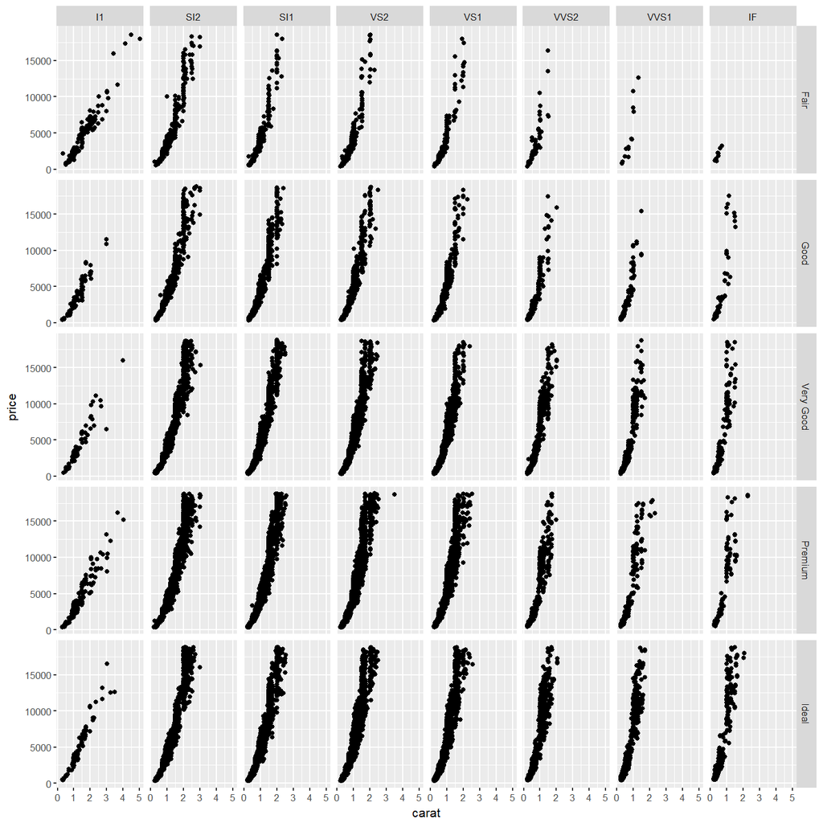

```r
ggplot(diamonds, aes(x = carat, y = price)) + geom_point() +  facet_grid(cut ~ clarity)
```

#### Plotting the Cars93 data

This problem uses the Cars93 dataset from the MASS package.

**(a)** Use `qplot` to create a scatterplot with Price on the y-axis and EngineSize on the `x-axis`.

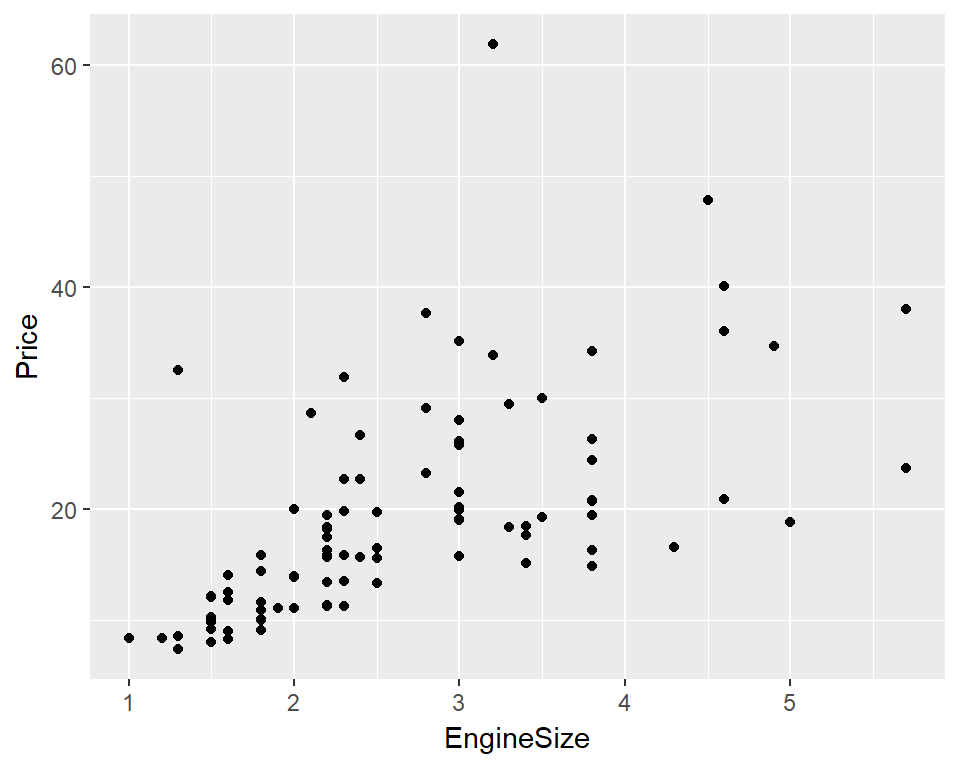

```r
qplot(x = EngineSize, y = Price, data = Cars93)
```

**(b)** Repeat part (a) using the `ggplot` function and `geom_point()` layer.

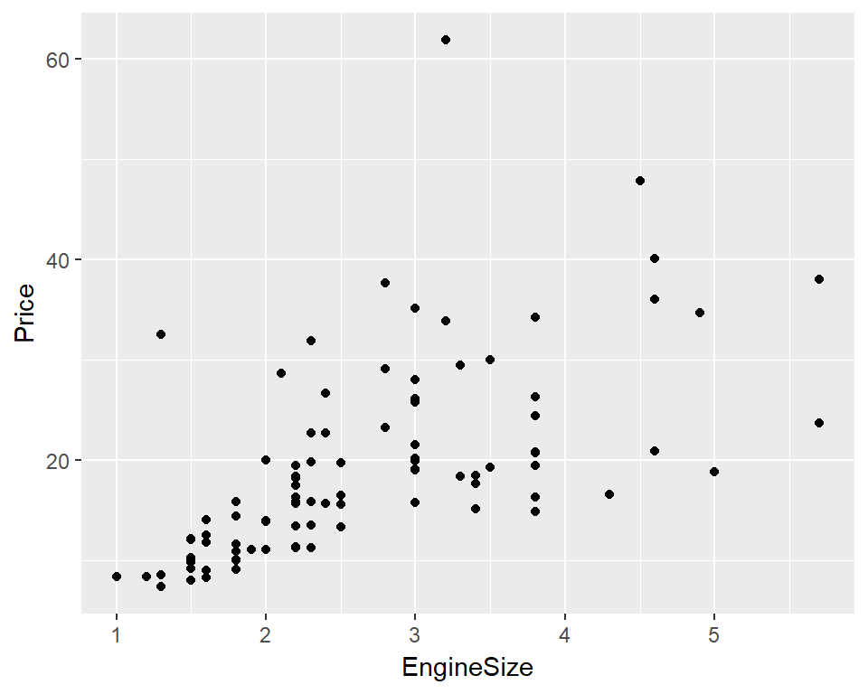

```r
ggplot(Cars93, aes(x = EngineSize, y = Price)) + geom_point()
```

**(c)** Repeat part (c), but this time specifying that the `color` mapping should depend on `Type` and the `shape` mapping should depend on `DriveTrain`.

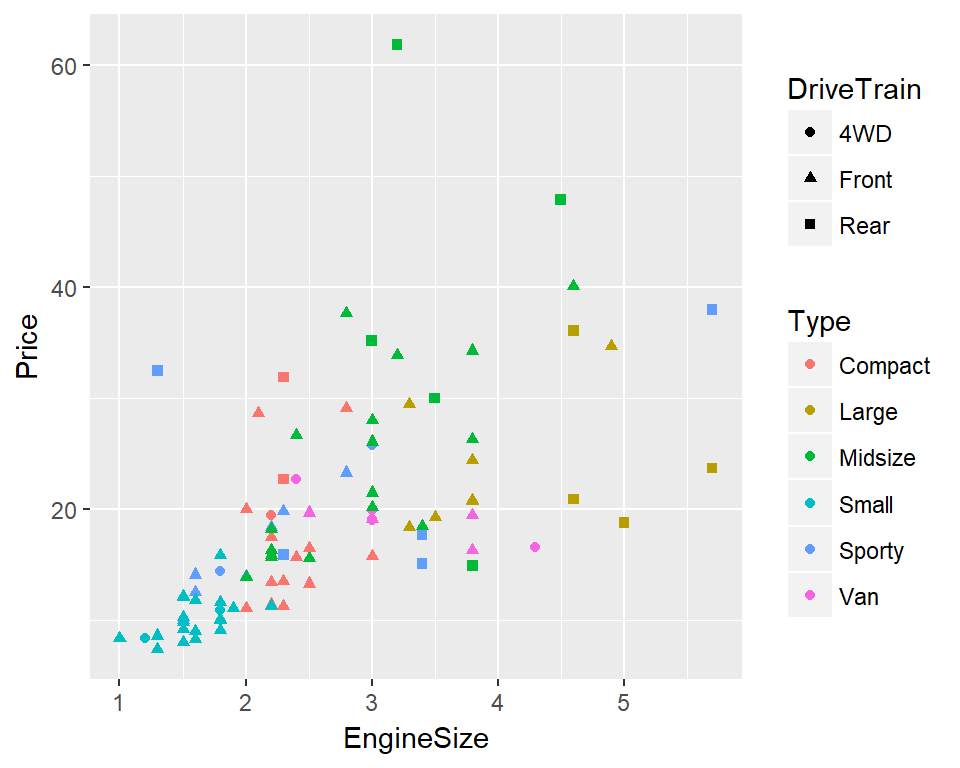

```r
ggplot(Cars93, aes(x = EngineSize, y = Price, colour = Type, shape = DriveTrain)) + geom_point()
```

#### Plotting a map

At the end of lecture we used the following code to generate a headmap of murder rates in the US.

```r
library(maps)
# Create data frame for map data (US states)
states <- map_data("state")

# Here's what the states data frame looks like
str(states)
```

```
## 'data.frame':    15537 obs. of  6 variables:
##  $ long     : num  -87.5 -87.5 -87.5 -87.5 -87.6 ...
##  $ lat      : num  30.4 30.4 30.4 30.3 30.3 ...
##  $ group    : num  1 1 1 1 1 1 1 1 1 1 ...
##  $ order    : int  1 2 3 4 5 6 7 8 9 10 ...
##  $ region   : chr  "alabama" "alabama" "alabama" "alabama" ...
##  $ subregion: chr  NA NA NA NA ...
```

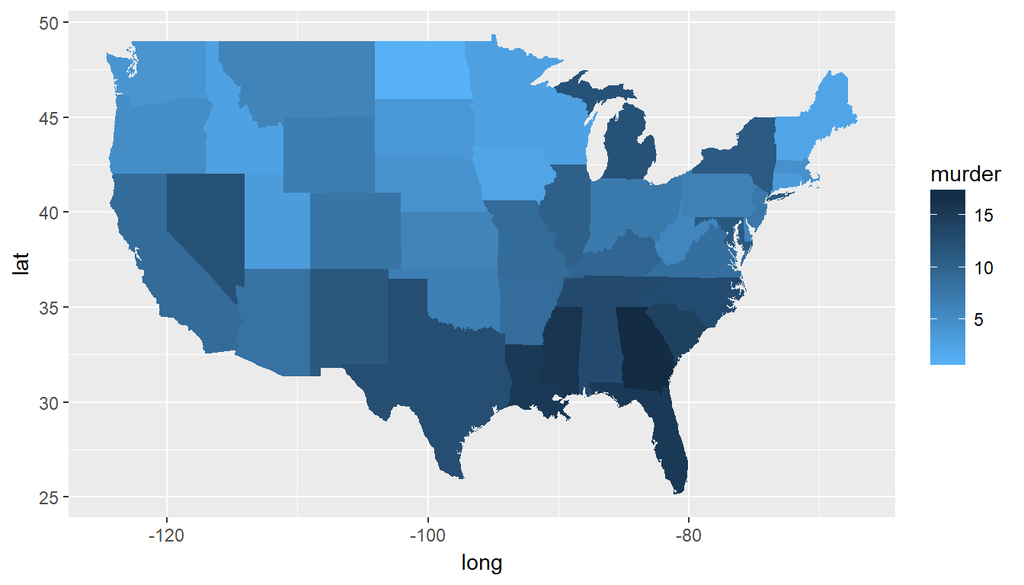

```r
# Make a copy of the data frame to manipulate
arrests <- USArrests

# Convert everything to lower case
names(arrests) <- tolower(names(arrests))
arrests$region <- tolower(rownames(USArrests))

# Merge the map data with the arrests data based on region
choro <- merge(states, arrests, sort = FALSE, by = "region")
choro <- choro[order(choro$order), ]

# Plot a map, filling in the states based on murder rate
qplot(long, lat, data = choro, group = group, fill = murder,
  geom = "polygon") + scale_fill_gradient(low = "#56B1F7", high = "#132B43")
```

Here’s a document that may help you pick colors: [Hex colour picker](https://www.w3schools.com/colors/colors_picker.asp)